# BasregDWH User Guide: Access data in Basreg

Tomas Klingström

2026-06-01

# Introduction

This guide helps you access the SLU Basreg database (**basregDWH**) using R and RStudio.

You will learn how to:

- Connect to the server using your SLU credentials
- Browse available tables and views
- Filter and handle large datasets before downloading them

If you are unfamiliar with Rstudio, Posit (the maker of Rstudio) describes the interface here: https://docs.posit.co/ide/user/ide/guide/ui/ui-panes.html

If you are reading this documentation with the intention of using it for data analysis. Please make sure you understand how R projects work: https://docs.posit.co/ide/user/ide/guide/code/projects.html

**Important:** Users have **read-only access**.  
This means you can view and download data, but you are **not at risk of changing the database**.

## Software prerequisites

You need:

1. **RStudio**  
   Official getting started guide:  
   https://docs.posit.co/ide/user/ide/get-started/
2. **Access to SLU Basreg / BasregDWH**  
   For permissions, contact: **Eva Rundlöf**
3. **Either being at a SLU campus or use the SLU VPN**  
   How to use VPN:  
   https://internt.slu.se/en/support-services/administrative-support/it/support/guider-manualer/vpn-anyconnect/

If you have a Windows-laptop issued by SLU, ODBC will automatically verify your identity when connecting. Linux and Mac users need to follow a separate instruction.

## Optional: Git + GitHub (recommended)

If you want to keep your work organised, you can use Git directly in RStudio:  
https://docs.posit.co/ide/user/ide/guide/tools/version-control.html

## Download this guide from GitHub

Repository:  
https://github.com/TKlingstrom/Basreg_introduction

You can download it in two ways:

### Option A: Clone with Git in RStudio (recommended)

1. In RStudio: **File → New Project → Version Control → Git**
2. Paste the repo URL
3. Choose a folder and click **Create Project**

### Option B: Download as a ZIP

1. Open the repository in your browser
2. Click **Code → Download ZIP**
3. Unzip and open the `.Rproj` file in RStudio

## Working with this guide

Preferably you follow the guide directly in R-markdown. To do this you open basreg_userguide.Rmd with Rstudio or open Rstudio and select **File → Open project in new session**.

You can also create your own R-script (In RStudio: **File → New File → R-script**) and copy the code from the HTML file (or PDF).

The difference between R markdown and an R-script is that in markdown you can run and rerun your code in “chunks”. Chunks are grey coloured and got a small green play arrow in the upper right corner. The output from running the code is displayed right below the code. R markdown can also easily be converted into a PDF or html file. I recommend that you follow this guide directly in the R markdown file or, alternatively open the HTML file in your browser and then write the code into an R-script. In the R markdown file you can scroll down until you find this text and then begin the tutorial below. Each code chunk must be run at least once (Clicking the green play button in the upper right corner of the markdown file or by copying it into your R script, selecting it and hitting CTRL + Enter). You can modify the code and rerun it as you wish, the name to the left of the <-will be the name of the object generated by the code and can be accessed in the Environment tab (top right pane).

We use these packages which must be installed and loaded (run the code below):

- **odbc**: database driver connection
- **DBI**: database interface
- **dplyr**: data manipulation
- **dbplyr**: makes dplyr work with databases
- **ggplot2**: is used later for plotting data

## Install packages (only needed once)

```r
install.packages(c("odbc", "DBI", "dplyr", "dbplyr", "ggplot2"))
```

## Load packages (needed every session)

```r
library(odbc)
library(DBI)
library(dplyr)
library(dbplyr)
library(ggplot2)
```

# Check your R session

## Check your current working directory

This is where R reads/writes files (e.g. exports).

```r
getwd()
```

To change folder:

```r
#If necessary, remove the # below and set your working directory to the Basreg_introduction folder
#setwd("C:/path/to/your/folder")
```

# Step 1: Connect to BasregDWH

This chunk creates a **connection object** called `con`.

Think of `con` as the way to tell your Rstudio session to connect to the Basreg server.

You do **not** download the whole database into your computer.  
Instead, you send requests to the server to collect data from SQL views.

A view is a way to present information in an SQL server and contain primarily observation-level data (events, measurements). Due to the way Basreg was developed it also contain some less useful columns necessary for other ways to interact with Basreg.

```r
# Connecting to the database using your R/Windows user credentials
con <- dbConnect(
  odbc(),
  Driver = "SQL Server",
  Server = "basregdwh.db.slu.se",
  Database = "basregDWH"
)

# List objects available in the apiSci schema
odbcListObjects(con, catalog = "basregDWH", schema = "apiSci")
```

| name | type |
| --- | --- |
| bridgeTrialsCattleFeedIntakeView | view |
| bridgeTrialsCattleHealthView | view |
| bridgeTrialsCattleHerdView | view |
| bridgeTrialsCattleMilkingParlourView | view |
| bridgeTrialsCattleMilkingView | view |
| bridgeTrialsCattleReproductionView | view |
| bridgeTrialsCattleSlaughterView | view |
| bridgeTrialsCattleWeightsView | view |
| bridgeTrialsPigBackFatsView | view |
| bridgeTrialsPigFarrowingsView | view |

[output cut: 23 more lines]

# Step 2: Preview a view (download only a few rows)

The function `tbl()` creates a reference to a database table/view specified in the paranthesis.

Thanks to dbplyr you can filter or manipulate the data before downloading it. In this case:

- `head(10)` limits to a small preview
- `collect()` downloads those rows into R as a data frame

The %>% is how you define the different steps dplyr and dbplyr will take in a `pipe` when filtering or manipulating data. Writing DF.Cow after the pipe then shows the output to you. In the environment tab (upper right pane in Rstudio) you also see all objects you create. Clicking the blue circle before them shows the datatype and clicking the table far to the right will you a table with the contents of the dataframe. The Connections tab to the right of Environment also show you all the database schemas you can access, if you have access you can click the blue circle and see what is inside of it. The views we will work with are located in **basregDWH → apiSci** and starts with “fact”.

```r
DF.Cow <- con %>%
  tbl(in_catalog("basregDWH", "apiSci", "factCattleView")) %>%
  head(10) %>%
  collect()

DF.Cow
```

| Farm | SE_Number | DelProID | CeresCattleNumber | CeresTransponderID | Gender | Species | BreedName | BirthDate | BirthWeight | Mother | Father | CullDecisionDate | CullReason1 | CullReason2 | ExitDate | SerialNo | BornHerdNo | DeathDate | ArrivalDate | Dissected | DissectedDate | Carrier | BreedPart1 | BreedPart1% | BreedPart2 | BreedPart2% | BreedPart3 | BreedPart3% | BreedPart4 | … |
| --- | --- | --- | --- | --- | --- | --- | --- | --- | --- | --- | --- | --- | --- | --- | --- | --- | --- | --- | --- | --- | --- | --- | --- | --- | --- | --- | --- | --- | --- | --- |
| Lövsta | 1 | 1 | NA | NA | Female | Cattle | 01 SRB | 2018-09-13 | NA | NA | NA | NA | NA | NA | 2020-03-06 | NA | NA | NA | 2018-09-13 | NA | NA | NA | NA | NA | NA | NA | NA | NA | NA | … |
| Lövsta | 2 | 2 | NA | NA | Female | Cattle | 01 SRB | 2018-09-13 | NA | NA | NA | NA | NA | NA | 2020-03-06 | NA | NA | NA | 2018-09-13 | NA | NA | NA | NA | NA | NA | NA | NA | NA | NA | … |
| Lövsta | SE-088270-0031 | 31 | NA | NA | Female | Cattle | 01 SRB | 2011-08-19 | NA | NA | NA | NA | NA | NA | 2021-12-06 | NA | NA | NA | 2011-09-19 | NA | NA | NA | NA | NA | NA | NA | NA | NA | NA | … |
| Lövsta | SE-088270-0080 | 80 | NA | NA | Female | Cattle | 01 SRB | 2011-11-25 | NA | SE-040852-1577 | UnknownSemen | 2020-08-05 | 12 Hög ålder | 09 Benlidande | 2020-11-05 | NA | NA | NA | 2011-11-25 | NA | NA | NA | NA | NA | NA | NA | NA | NA | NA | … |
| Lövsta | SE-088270-0228 | 228 | NA | NA | Female | Cattle | 01 SRB | 2012-12-07 | NA | SE-040852-1588 | 22-6558 R-Haslev | 2020-10-23 | 04 Mastit/juverfel | 12 Hög ålder | 2021-01-13 | NA | NA | NA | 2012-12-07 | NA | NA | NA | NA | NA | NA | NA | NA | NA | NA | … |
| Lövsta | SE-088270-0235 | 235 | NA | NA | Female | Cattle | 01 SRB | 2012-12-19 | NA | SE-040852-1450 | 22-7012 VR Eragon | 2020-08-25 | 12 Hög ålder | NA | 2020-09-14 | NA | NA | NA | 2012-12-19 | NA | NA | NA | NA | NA | NA | NA | NA | NA | NA | … |
| Lövsta | SE-088270-0270 | 270 | NA | NA | Female | Cattle | 01 SRB | 2013-03-07 | NA | SE-040852-1663 | 22-7012 VR Eragon | 2021-08-10 | 04 Mastit/juverfel | NA | 2021-12-21 | NA | NA | NA | 2013-03-07 | NA | NA | NA | NA | NA | NA | NA | NA | NA | NA | … |
| Lövsta | SE-088270-0279 | 279 | NA | NA | Female | Cattle | 02 SLB | 2013-04-16 | NA | SE-081385-0362 | 9-3249 VH OP | 2020-07-22 | 04 Mastit/juverfel | NA | 2021-01-13 | NA | NA | NA | 2013-04-16 | NA | NA | NA | NA | NA | NA | NA | NA | NA | NA | … |
| Lövsta | SE-088270-0282 | 282 | NA | NA | Female | Cattle | 01 SRB | 2013-04-30 | NA | SE-040852-1669 | 22-5813 VR Freak | 2020-07-16 | 12 Hög ålder | 13 Låg avkastning | 2020-08-27 | NA | NA | NA | 2019-02-08 | NA | NA | NA | NA | NA | NA | NA | NA | NA | NA | … |
| Lövsta | SE-088270-0286 | 286 | NA | NA | Female | Cattle | 01 SRB | 2013-05-18 | NA | SE-040852-1679 | 22-5813 VR Freak | NA | NA | NA | 2020-06-27 | NA | NA | NA | 2013-05-18 | NA | NA | NA | NA | NA | NA | NA | NA | NA | NA | … |

Try switching the object name in the code above, for example:

- `"factCattleView"` to
- `"factCattleReproductionView"`

# Step 3: Filtering rows (sparse views are common)

Many Basreg views are **sparse**.

That means most rows contain only a few filled columns and many `NA`.

Filtering helps you select only meaningful rows.

Example:

- `!is.na(Calving)` means: keep only rows where Calving exists
- In this dataset, **StartDate** contains the date of the event
- Switching to `DryOff` instead gives dry-off events

```r
DF.Reproduction <- con %>%
  tbl(in_catalog("basregDWH", "apiSci", "factCattleReproductionView")) %>%
  filter(!is.na(Calving)) %>%
  collect()

DF.Reproduction
```

| Farm | Place | Equipment | SE_Number | DelProId | BiocontrolId | CeresCattleNumber | dimCattle_Id | StartDate | StartTime | InseminationMethod | SemenId | PregnancyCheckResult | Calving | CalvingEase | ExpectedCalvingDate | ExpectedDryOffDate | DryOff | BiometricType | SmoothedLevel | RawLevel | Heat | InseminationNumber | LactationNumber | NumberOfDaysInLactation | SourceLocation | factCattleReproduction_Id |
| --- | --- | --- | --- | --- | --- | --- | --- | --- | --- | --- | --- | --- | --- | --- | --- | --- | --- | --- | --- | --- | --- | --- | --- | --- | --- | --- |
| Lövsta | Lövsta | Unknown | SE-088270-0031 | 31 | NA | NA | 3 | 2020-01-11 | NA | Unknown | Unknown | Unknown | 1 | 11 Lätt, utan hjälp | NA | NA | NA | Unknown | NA | NA | NA | NA | NA | NA | \\\\storage-ua.slu.se\\Basreg_prod$\\FileArea\\ImportArea\\07_6_REPRO_Calving_Data_v1.6.0.0_gen20201214_20200111.csv | 53385 |
| Lövsta | Lövsta | Unknown | SE-088270-0031 | 31 | NA | NA | 3 | 2021-02-25 | NA | Unknown | Unknown | Unknown | 1 | 11 Lätt, utan hjälp | NA | NA | NA | Unknown | NA | NA | NA | NA | NA | NA | \\\\storage-ua.slu.se\\Basreg_prod$\\FileArea\\ImportArea\\07_6_REPRO_Calving_Data_v1.6.1.0_gen20210226_20210225.csv | 58780 |
| Lövsta | Lövsta | Unknown | SE-088270-0080 | 80 | NA | NA | 4 | 2020-05-02 | NA | Unknown | Unknown | Unknown | 1 | 11 Lätt, utan hjälp | NA | NA | NA | Unknown | NA | NA | NA | NA | NA | NA | \\\\storage-ua.slu.se\\Basreg_prod$\\FileArea\\ImportArea\\07_6_REPRO_Calving_Data_v1.6.0.0_gen20201214_20200502.csv | 53534 |
| Lövsta | Lövsta | Unknown | SE-088270-0228 | 228 | NA | NA | 5 | 2020-10-16 | NA | Unknown | Unknown | Unknown | 1 | 11 Lätt, utan hjälp | NA | NA | NA | Unknown | NA | NA | NA | NA | NA | NA | \\\\storage-ua.slu.se\\Basreg_prod$\\FileArea\\ImportArea\\07_6_REPRO_Calving_Data_v1.6.0.0_gen20201214_20201016.csv | 53379 |
| Lövsta | Lövsta | Unknown | SE-088270-0235 | 235 | NA | NA | 6 | 2020-07-05 | NA | Unknown | Unknown | Unknown | 1 | 11 Lätt, utan hjälp | NA | NA | NA | Unknown | NA | NA | NA | NA | NA | NA | \\\\storage-ua.slu.se\\Basreg_prod$\\FileArea\\ImportArea\\07_6_REPRO_Calving_Data_v1.6.0.0_gen20201214_20200705.csv | 53380 |
| Lövsta | Lövsta | Unknown | SE-088270-0270 | 270 | NA | NA | 7 | 2020-08-18 | NA | Unknown | Unknown | Unknown | 1 | 12 Lätt, med hjälp | NA | NA | NA | Unknown | NA | NA | NA | NA | NA | NA | \\\\storage-ua.slu.se\\Basreg_prod$\\FileArea\\ImportArea\\07_6_REPRO_Calving_Data_v1.6.0.0_gen20201214_20200818.csv | 53381 |
| Lövsta | Lövsta | Unknown | SE-088270-0270 | 270 | NA | NA | 7 | 2021-11-20 | NA | Unknown | Unknown | Unknown | 1 | 12 Lätt, med hjälp | NA | NA | NA | Unknown | NA | NA | NA | NA | NA | NA | \\\\storage-ua.slu.se\\Basreg$\\FileArea\\ImportArea\\Lovsta\\07_6_REPRO_Calving_Data_v1.6.1.0_gen20211123_20211120.csv | 111071 |
| Lövsta | Lövsta | Unknown | SE-088270-0279 | 279 | NA | NA | 8 | 2020-07-14 | NA | Unknown | Unknown | Unknown | 1 | 12 Lätt, med hjälp | NA | NA | NA | Unknown | NA | NA | NA | NA | NA | NA | \\\\storage-ua.slu.se\\Basreg_prod$\\FileArea\\ImportArea\\07_6_REPRO_Calving_Data_v1.6.0.0_gen20201214_20200714.csv | 53382 |
| Lövsta | Lövsta | Unknown | SE-088270-0282 | 282 | NA | NA | 9 | 2020-06-23 | NA | Unknown | Unknown | Unknown | 1 | 11 Lätt, utan hjälp | NA | NA | NA | Unknown | NA | NA | NA | NA | NA | NA | \\\\storage-ua.slu.se\\Basreg_prod$\\FileArea\\ImportArea\\07_6_REPRO_Calving_Data_v1.6.0.0_gen20201214_20200623.csv | 53383 |
| Lövsta | Lövsta | Unknown | SE-088270-0286 | 286 | NA | NA | 10 | 2020-06-08 | NA | Unknown | Unknown | Unknown | 1 | 11 Lätt, utan hjälp | NA | NA | NA | Unknown | NA | NA | NA | NA | NA | NA | \\\\storage-ua.slu.se\\Basreg_prod$\\FileArea\\ImportArea\\07_6_REPRO_Calving_Data_v1.6.0.0_gen20201214_20200608.csv | 53384 |

[output cut: 2654 more lines]

# Step 4: Multiple filters (ALL must be true)

You can combine filters.

In `filter()`, multiple conditions mean:

condition 1 **AND** condition 2 **AND** condition 3

Here we select:

- rows with Calving events (the value in the column Calving is not NA)
- only events between 2021-01-01 and 2021-01-31 (the value in column StartDate is equal or after 2021-01-01 but equal or before 2021-01-31)

```r
DF.Reproduction <- con %>%
  tbl(in_catalog("basregDWH", "apiSci", "factCattleReproductionView")) %>%
  filter(
    !is.na(Calving),
    StartDate >= as.Date("2021-01-01"),
    StartDate <= as.Date("2021-01-31")
  ) %>%
  collect()

DF.Reproduction
```

| Farm | Place | Equipment | SE_Number | DelProId | BiocontrolId | CeresCattleNumber | dimCattle_Id | StartDate | StartTime | InseminationMethod | SemenId | PregnancyCheckResult | Calving | CalvingEase | ExpectedCalvingDate | ExpectedDryOffDate | DryOff | BiometricType | SmoothedLevel | RawLevel | Heat | InseminationNumber | LactationNumber | NumberOfDaysInLactation | SourceLocation | factCattleReproduction_Id |
| --- | --- | --- | --- | --- | --- | --- | --- | --- | --- | --- | --- | --- | --- | --- | --- | --- | --- | --- | --- | --- | --- | --- | --- | --- | --- | --- |
| Lövsta | Lövsta | Unknown | SE-088270-2008 | 2008 | NA | NA | 291 | 2021-01-20 | NA | Unknown | Unknown | Unknown | 1 | 11 Lätt, utan hjälp | NA | NA | NA | Unknown | NA | NA | NA | NA | NA | NA | \\\\storage-ua.slu.se\\Basreg_prod$\\FileArea\\ImportArea\\07_6_REPRO_Calving_Data_v1.6.0.0_gen20210130_20210120.csv | 53244 |
| Lövsta | Lövsta | Unknown | SE-088270-2010 | 2010 | NA | NA | 293 | 2021-01-07 | NA | Unknown | Unknown | Unknown | 1 | 12 Lätt, med hjälp | NA | NA | NA | Unknown | NA | NA | NA | NA | NA | NA | \\\\storage-ua.slu.se\\Basreg_prod$\\FileArea\\ImportArea\\07_6_REPRO_Calving_Data_v1.6.0.0_gen20210115_20210107.csv | 53247 |
| Lövsta | Lövsta | Unknown | SE-088270-2013 | 2013 | NA | NA | 296 | 2021-01-05 | NA | Unknown | Unknown | Unknown | 1 | 11 Lätt, utan hjälp | NA | NA | NA | Unknown | NA | NA | NA | NA | NA | NA | \\\\storage-ua.slu.se\\Basreg_prod$\\FileArea\\ImportArea\\07_6_REPRO_Calving_Data_v1.6.0.0_gen20210115_20210105.csv | 53251 |
| Lövsta | Lövsta | Unknown | SE-088270-2014 | 2014 | NA | NA | 297 | 2021-01-18 | NA | Unknown | Unknown | Unknown | 1 | 11 Lätt, utan hjälp | NA | NA | NA | Unknown | NA | NA | NA | NA | NA | NA | \\\\storage-ua.slu.se\\Basreg_prod$\\FileArea\\ImportArea\\07_6_REPRO_Calving_Data_v1.6.0.0_gen20210129_20210118.csv | 53253 |
| Lövsta | Lövsta | Unknown | SE-088270-2136 | 2136 | NA | NA | 391 | 2021-01-07 | NA | Unknown | Unknown | Unknown | 1 | 12 Lätt, med hjälp | NA | NA | NA | Unknown | NA | NA | NA | NA | NA | NA | \\\\storage-ua.slu.se\\Basreg_prod$\\FileArea\\ImportArea\\07_6_REPRO_Calving_Data_v1.6.0.0_gen20210115_20210107.csv | 53342 |
| Lövsta | Lövsta | Unknown | SE-088270-2155 | 2155 | NA | NA | 404 | 2021-01-18 | NA | Unknown | Unknown | Unknown | 1 | 12 Lätt, med hjälp | NA | NA | NA | Unknown | NA | NA | NA | NA | NA | NA | \\\\storage-ua.slu.se\\Basreg_prod$\\FileArea\\ImportArea\\07_6_REPRO_Calving_Data_v1.6.0.0_gen20210129_20210118.csv | 53355 |
| Lövsta | Lövsta | Unknown | SE-088270-2170 | 2170 | NA | NA | 417 | 2021-01-12 | NA | Unknown | Unknown | Unknown | 1 | 11 Lätt, utan hjälp | NA | NA | NA | Unknown | NA | NA | NA | NA | NA | NA | \\\\storage-ua.slu.se\\Basreg_prod$\\FileArea\\ImportArea\\07_6_REPRO_Calving_Data_v1.6.0.0_gen20210115_20210112.csv | 53368 |
| Lövsta | Lövsta | Unknown | SE-088270-2171 | 2171 | NA | NA | 418 | 2021-01-01 | NA | Unknown | Unknown | Unknown | 1 | 11 Lätt, utan hjälp | NA | NA | NA | Unknown | NA | NA | NA | NA | NA | NA | \\\\storage-ua.slu.se\\Basreg_prod$\\FileArea\\ImportArea\\07_6_REPRO_Calving_Data_v1.6.0.0_gen20210111_20210101.csv | 53369 |
| Lövsta | Lövsta | Unknown | SE-088270-2172 | 2172 | NA | NA | 419 | 2021-01-07 | NA | Unknown | Unknown | Unknown | 1 | 12 Lätt, med hjälp | NA | NA | NA | Unknown | NA | NA | NA | NA | NA | NA | \\\\storage-ua.slu.se\\Basreg_prod$\\FileArea\\ImportArea\\07_6_REPRO_Calving_Data_v1.6.0.0_gen20210115_20210107.csv | 53370 |
| Lövsta | Lövsta | Unknown | SE-088270-2173 | 2173 | NA | NA | 420 | 2021-01-20 | NA | Unknown | Unknown | Unknown | 1 | 12 Lätt, med hjälp | NA | NA | NA | Unknown | NA | NA | NA | NA | NA | NA | \\\\storage-ua.slu.se\\Basreg_prod$\\FileArea\\ImportArea\\07_6_REPRO_Calving_Data_v1.6.0.0_gen20210130_20210120.csv | 53371 |

[output cut: 19 more lines]

# Step 5: OR filters (either condition can be true)

Sometimes you want either:

- Calving events **OR**
- DryOff events

In R:

- `|` means **OR**
- `&` means **AND** (commas also work as you saw above)

Here we select:

- rows where Calving exists OR DryOff exists
- but still only within January 2021

```r
DF.Reproduction <- con %>%
  tbl(in_catalog("basregDWH", "apiSci", "factCattleReproductionView")) %>%
  filter(
    (!is.na(Calving) | !is.na(DryOff)),
    StartDate >= as.Date("2021-01-01"),
    StartDate <= as.Date("2021-01-31")
  ) %>%
  collect()

DF.Reproduction
```

| Farm | Place | Equipment | SE_Number | DelProId | BiocontrolId | CeresCattleNumber | dimCattle_Id | StartDate | StartTime | InseminationMethod | SemenId | PregnancyCheckResult | Calving | CalvingEase | ExpectedCalvingDate | ExpectedDryOffDate | DryOff | BiometricType | SmoothedLevel | RawLevel | Heat | InseminationNumber | LactationNumber | NumberOfDaysInLactation | SourceLocation | factCattleReproduction_Id |
| --- | --- | --- | --- | --- | --- | --- | --- | --- | --- | --- | --- | --- | --- | --- | --- | --- | --- | --- | --- | --- | --- | --- | --- | --- | --- | --- |
| Lövsta | Lövsta | Unknown | SE-088270-2005 | 2005 | NA | NA | 289 | 2021-01-04 | NA | Unknown | Unknown | Unknown | NA | Unknown | NA | NA | 1 | Unknown | NA | NA | NA | NA | NA | NA | \\\\storage-ua.slu.se\\Basreg_prod$\\FileArea\\ImportArea\\07_4_REPRO_DryOff_Data_v1.6.0.0_gen20210114_20210104.csv | 898 |
| Lövsta | Lövsta | Unknown | SE-088270-2012 | 2012 | NA | NA | 295 | 2021-01-08 | NA | Unknown | Unknown | Unknown | NA | Unknown | NA | NA | 1 | Unknown | NA | NA | NA | NA | NA | NA | \\\\storage-ua.slu.se\\Basreg_prod$\\FileArea\\ImportArea\\07_4_REPRO_DryOff_Data_v1.6.0.0_gen20210115_20210108.csv | 904 |
| Lövsta | Lövsta | Unknown | SE-088270-2027 | 2027 | NA | NA | 305 | 2021-01-22 | NA | Unknown | Unknown | Unknown | NA | Unknown | NA | NA | 1 | Unknown | NA | NA | NA | NA | NA | NA | \\\\storage-ua.slu.se\\Basreg_prod$\\FileArea\\ImportArea\\07_4_REPRO_DryOff_Data_v1.6.0.0_gen20210201_20210122.csv | 911 |
| Lövsta | Lövsta | Unknown | SE-088270-2029 | 2029 | NA | NA | 307 | 2021-01-04 | NA | Unknown | Unknown | Unknown | NA | Unknown | NA | NA | 1 | Unknown | NA | NA | NA | NA | NA | NA | \\\\storage-ua.slu.se\\Basreg_prod$\\FileArea\\ImportArea\\07_4_REPRO_DryOff_Data_v1.6.0.0_gen20210114_20210104.csv | 912 |
| Lövsta | Lövsta | Unknown | SE-088270-2030 | 2030 | NA | NA | 308 | 2021-01-22 | NA | Unknown | Unknown | Unknown | NA | Unknown | NA | NA | 1 | Unknown | NA | NA | NA | NA | NA | NA | \\\\storage-ua.slu.se\\Basreg_prod$\\FileArea\\ImportArea\\07_4_REPRO_DryOff_Data_v1.6.0.0_gen20210201_20210122.csv | 913 |
| Lövsta | Lövsta | Unknown | SE-088270-2032 | 2032 | NA | NA | 310 | 2021-01-15 | NA | Unknown | Unknown | Unknown | NA | Unknown | NA | NA | 1 | Unknown | NA | NA | NA | NA | NA | NA | \\\\storage-ua.slu.se\\Basreg_prod$\\FileArea\\ImportArea\\07_4_REPRO_DryOff_Data_v1.6.0.0_gen20210117_20210115.csv | 915 |
| Lövsta | Lövsta | Unknown | SE-088270-2034 | 2034 | NA | NA | 311 | 2021-01-08 | NA | Unknown | Unknown | Unknown | NA | Unknown | NA | NA | 1 | Unknown | NA | NA | NA | NA | NA | NA | \\\\storage-ua.slu.se\\Basreg_prod$\\FileArea\\ImportArea\\07_4_REPRO_DryOff_Data_v1.6.0.0_gen20210115_20210108.csv | 916 |
| Lövsta | Lövsta | Unknown | SE-088270-2040 | 2040 | NA | NA | 314 | 2021-01-22 | NA | Unknown | Unknown | Unknown | NA | Unknown | NA | NA | 1 | Unknown | NA | NA | NA | NA | NA | NA | \\\\storage-ua.slu.se\\Basreg_prod$\\FileArea\\ImportArea\\07_4_REPRO_DryOff_Data_v1.6.0.0_gen20210201_20210122.csv | 918 |
| Lövsta | Lövsta | Unknown | SE-088270-2042 | 2042 | NA | NA | 316 | 2021-01-15 | NA | Unknown | Unknown | Unknown | NA | Unknown | NA | NA | 1 | Unknown | NA | NA | NA | NA | NA | NA | \\\\storage-ua.slu.se\\Basreg_prod$\\FileArea\\ImportArea\\07_4_REPRO_DryOff_Data_v1.6.0.0_gen20210117_20210115.csv | 919 |
| Lövsta | Lövsta | Unknown | SE-088270-2045 | 2045 | NA | NA | 319 | 2021-01-04 | NA | Unknown | Unknown | Unknown | NA | Unknown | NA | NA | 1 | Unknown | NA | NA | NA | NA | NA | NA | \\\\storage-ua.slu.se\\Basreg_prod$\\FileArea\\ImportArea\\07_4_REPRO_DryOff_Data_v1.6.0.0_gen20210114_20210104.csv | 922 |

[output cut: 46 more lines]

# Step 6: Select columns (download only what you need)

In Basreg views there are often many columns, The function select() keeps only the columns you specify. Everything else is removed from the download.

Here we reuse the same query as in Step 5 (Calving or DryOff events in January 2021), but only collect the most important columns.

```r
DF.Reproduction <- con %>%
  tbl(in_catalog("basregDWH", "apiSci", "factCattleReproductionView")) %>%
  filter(
    (!is.na(Calving) | !is.na(DryOff)),
    StartDate >= as.Date("2021-01-01"),
    StartDate <= as.Date("2021-01-31")
  ) %>%
  select(Farm, SE_Number, StartDate, Calving, CalvingEase, DryOff) %>%
  collect()

DF.Reproduction
```

| Farm | SE_Number | StartDate | Calving | CalvingEase | DryOff |
| --- | --- | --- | --- | --- | --- |
| Lövsta | SE-088270-2005 | 2021-01-04 | NA | Unknown | 1 |
| Lövsta | SE-088270-2012 | 2021-01-08 | NA | Unknown | 1 |
| Lövsta | SE-088270-2027 | 2021-01-22 | NA | Unknown | 1 |
| Lövsta | SE-088270-2029 | 2021-01-04 | NA | Unknown | 1 |
| Lövsta | SE-088270-2030 | 2021-01-22 | NA | Unknown | 1 |
| Lövsta | SE-088270-2032 | 2021-01-15 | NA | Unknown | 1 |
| Lövsta | SE-088270-2034 | 2021-01-08 | NA | Unknown | 1 |
| Lövsta | SE-088270-2040 | 2021-01-22 | NA | Unknown | 1 |
| Lövsta | SE-088270-2042 | 2021-01-15 | NA | Unknown | 1 |
| Lövsta | SE-088270-2045 | 2021-01-04 | NA | Unknown | 1 |

[output cut: 46 more lines]

# Step 7: Modifying columns

We will now modify the view before downloading it from the server.

In the chunk below we remove the columns `Calving`, `DryOff` and `StartDate` and with the mutate function instead create:

- `CalvingDate` which contains the date of the calving (from `StartDate`)
- `DryOffDate` which contains the date of the dry-off (from `StartDate`)

This makes the dataset easier to interpret after downloading it.

```r
DF.Reproduction <- con %>%
  tbl(in_catalog("basregDWH", "apiSci", "factCattleReproductionView")) %>%
  filter(
    (!is.na(Calving) | !is.na(DryOff)),
    StartDate >= as.Date("2021-01-01"),
    StartDate <= as.Date("2021-01-31")
  ) %>%
  mutate(
    # mutate() creates new columns (or modifies existing ones)
    # Read more here: https://dplyr.tidyverse.org/reference/mutate.html
    CalvingDate = if_else(!is.na(Calving), StartDate, as.Date(NA)),
    DryOffDate  = if_else(!is.na(DryOff),  StartDate, as.Date(NA))
  ) %>%
  select(Farm, SE_Number, CalvingDate, DryOffDate, CalvingEase) %>%
  collect()

DF.Reproduction
```

| Farm | SE_Number | CalvingDate | DryOffDate | CalvingEase |
| --- | --- | --- | --- | --- |
| Lövsta | SE-088270-2005 | NA | 2021-01-04 | Unknown |
| Lövsta | SE-088270-2012 | NA | 2021-01-08 | Unknown |
| Lövsta | SE-088270-2027 | NA | 2021-01-22 | Unknown |
| Lövsta | SE-088270-2029 | NA | 2021-01-04 | Unknown |
| Lövsta | SE-088270-2030 | NA | 2021-01-22 | Unknown |
| Lövsta | SE-088270-2032 | NA | 2021-01-15 | Unknown |
| Lövsta | SE-088270-2034 | NA | 2021-01-08 | Unknown |
| Lövsta | SE-088270-2040 | NA | 2021-01-22 | Unknown |
| Lövsta | SE-088270-2042 | NA | 2021-01-15 | Unknown |
| Lövsta | SE-088270-2045 | NA | 2021-01-04 | Unknown |

[output cut: 46 more lines]

# Step 8: Combining information from multiple views

The reproduction view tells us when a calving happened, but it does not directly show which offspring cow was born from that event.

To connect the calving event to the offspring identity, we will combine two views:

- `factCattleReproductionView` contains calving information and calving dates
- `factCattleView` contains the offspring cow identity and the mother’s identity

In `factCattleView`, the mother’s SE-number is stored in the column `Mother`.

We will:

1. Extract `Farm`, `SE_Number`, `CalvingDate`, and `CalvingEase` from `factCattleReproductionView`
2. Extract `SE_Number` (offspring), `Mother`, and `BirthDate` from `factCattleView`
3. Match calving events by joining:
   - `SE_Number` (mother) = `Mother`
   - `CalvingDate` = `BirthDate`
4. Keep the calving information and rename the offspring `SE_Number` into `Offspring`

```r
# IMPORTANT:
# In this step we do NOT download (collect) the full views into R.
# Instead, dbplyr keeps the objects as "lazy" SQL queries that remain on the Basreg server.
# This means filter(), transmute() and inner_join() are translated into SQL and run server-side.
# Only when we call collect() at the end will the result be downloaded into R.
# Running computations server-side is appropriate when it reduces the amount of data you need to download. Running large computations serverside
# should however be avoided as it may impact other users.


#
# Read more here:
# - dbplyr basics (lazy queries): https://dbplyr.tidyverse.org/articles/dbplyr.html
# - dbplyr translation to SQL:   https://dbplyr.tidyverse.org/articles/translation.html

# 1) Prepare the calving events table (still server-side, NOT collected)
DF.ReproductionEvents <- con %>%
  tbl(in_catalog("basregDWH", "apiSci", "factCattleReproductionView")) %>%
  filter(
    !is.na(Calving),
    StartDate >= as.Date("2021-01-01"),
    StartDate <= as.Date("2021-01-31")
  ) %>%
  transmute(
    Farm = Farm,
    SE_Number = SE_Number,        # Mother identity in reproduction view
    CalvingDate = StartDate,      # Calving date is stored in StartDate
    CalvingEase = CalvingEase
  )

# 2) Prepare the cattle view with offspring information (still server-side, NOT collected)
DF.Cattle <- con %>%
  tbl(in_catalog("basregDWH", "apiSci", "factCattleView")) %>%
  transmute(
    Offspring = SE_Number,        # Offspring identity in cattle view
    Mother = Mother,              # Mother identity in cattle view
    BirthDate = BirthDate
  )

# 3) Join the two server-side objects in SQL Server and sort from first born to last born
DF.CalvingWithOffspring <- DF.ReproductionEvents %>%
  inner_join(
    DF.Cattle,
    by = c("SE_Number" = "Mother", "CalvingDate" = "BirthDate")
  ) %>%
  arrange(CalvingDate) %>%  # arrange() sorts the output by date (oldest first)
  select(Farm, SE_Number, Offspring, CalvingDate, CalvingEase) %>%
  collect()  # collect() runs the SQL query and downloads ONLY the final joined result into R

# 4) List any calving events that did not find an offspring match
DF.UnmatchedCalvings <- DF.ReproductionEvents %>%
  anti_join(
    DF.Cattle,
    by = c("SE_Number" = "Mother", "CalvingDate" = "BirthDate")
  ) %>%
  arrange(SE_Number, CalvingDate) %>%
  collect()

DF.CalvingWithOffspring #This table will contain all cases where we now have a Mother and a SE_Number for the calf.
```

| Farm | SE_Number | Offspring | CalvingDate | CalvingEase |
| --- | --- | --- | --- | --- |
| Lövsta | SE-088270-2171 | SE-088270-8422 | 2021-01-01 | 11 Lätt, utan hjälp |
| Lövsta | SE-088270-0551 | SE-088270-8423 | 2021-01-01 | 11 Lätt, utan hjälp |
| Lövsta | SE-088270-0592 | SE-088270-8425 | 2021-01-02 | 12 Lätt, med hjälp |
| Lövsta | SE-088270-0950 | SE-088270-8424 | 2021-01-02 | 12 Lätt, med hjälp |
| Lövsta | SE-088270-0790 | SE-088270-8426 | 2021-01-04 | 11 Lätt, utan hjälp |
| Lövsta | SE-088270-2177 | SE-088270-2526 | 2021-01-04 | 11 Lätt, utan hjälp |
| Lövsta | SE-088270-2013 | SE-088270-2527 | 2021-01-05 | 11 Lätt, utan hjälp |
| Lövsta | SE-088270-2178 | SE-088270-2528 | 2021-01-07 | 12 Lätt, med hjälp |
| Lövsta | SE-088270-2010 | SE-088270-8429 | 2021-01-07 | 12 Lätt, med hjälp |
| Lövsta | SE-088270-2172 | SE-088270-8428 | 2021-01-07 | 12 Lätt, med hjälp |

[output cut: 16 more lines]

```r
DF.UnmatchedCalvings  #This table will contain all cases where we could not find a Cow born on the right day with a mother giving birth that day.
```

| Farm | SE_Number | CalvingDate | CalvingEase |
| --- | --- | --- | --- |
| Lövsta | SE-088270-0824 | 2021-01-22 | 12 Lätt, med hjälp |
| Lövsta | SE-088270-0933 | 2021-01-05 | 13 Svår, utan veterinärhjälp |
| Lövsta | SE-088270-2187 | 2021-01-06 | 11 Lätt, utan hjälp |

# Step 9: Select milking records after each calving

We will now use the calving table we created in Step 8 to find milking records after each calving.

For each mother (`SE_Number`) and each `CalvingDate` in the calving table, we select rows from `factCattleMilkingView` where the milking date (`StartDate`) is within **365 days after the calving date**.

To do this efficiently, we keep the work **server-side** and join the views in SQL Server. Only the final result is downloaded when we use `collect()`.

```r
# IMPORTANT:
# We recreate the calving table as a server-side query (not collected),
# then join it to the milking view on the SQL server.
# This avoids looping in R and avoids downloading large views.
#
# Read more here:
# - dbplyr joins: https://dbplyr.tidyverse.org/articles/two-table.html
# - dbplyr SQL translation: https://dbplyr.tidyverse.org/articles/translation.html

# 1) Calving table (server-side, NOT collected)
DF.CalvingWithOffspring_db <- con %>%
  tbl(in_catalog("basregDWH", "apiSci", "factCattleReproductionView")) %>%
  filter(
    !is.na(Calving),
    StartDate >= as.Date("2021-01-01"),
    StartDate <= as.Date("2021-01-31")
  ) %>%
  transmute(
    Farm = Farm,
    SE_Number = SE_Number,     # Mother
    CalvingDate = StartDate,
    CalvingEase = CalvingEase
  ) %>%
  inner_join(
    con %>% tbl(in_catalog("basregDWH", "apiSci", "factCattleView")) %>%
      transmute(
        Offspring = SE_Number,
        Mother = Mother,
        BirthDate = BirthDate
      ),
    by = c("SE_Number" = "Mother", "CalvingDate" = "BirthDate")
  ) %>%
  select(Farm, SE_Number, Offspring, CalvingDate, CalvingEase)

# 2) Milking view (server-side, NOT collected)
DF.Milking <- con %>%
  tbl(in_catalog("basregDWH", "apiSci", "factCattleMilkingView"))

# 3) Join calvings to milking records and keep only milking within 365 days after each calving
DF.MilkingAfterCalving <- DF.CalvingWithOffspring_db %>%
  inner_join(DF.Milking, by = "SE_Number") %>%  # match milking records to the mother
  filter(
    StartDate >= CalvingDate,
    StartDate < sql("DATEADD(day, 365, CalvingDate)") #This is where the 365 day limit is kept
  ) %>%
  arrange(SE_Number, CalvingDate, StartDate) %>%  # sort from earliest to latest
  collect()  # download only the filtered result to R

DF.MilkingAfterCalving
```

| Farm.x | SE_Number | Offspring | CalvingDate | CalvingEase | Farm.y | Place | Equipment | DelProId | BiocontrolId | CeresCattleNumber | dimCattle_Id | StartDate | StartTime | Incompletes | KickOffs | NotMilked | MilkingDuration_sec | MilkFlowDuration_sec | MilkingInterval_sec | SessionNumber | TotalYieldLF | TotalYieldRF | TotalYieldLR | TotalYieldRR | TotalYield | AverageFlowLF | AverageFlowLR | AverageFlowRF | AverageFlowRR | … |
| --- | --- | --- | --- | --- | --- | --- | --- | --- | --- | --- | --- | --- | --- | --- | --- | --- | --- | --- | --- | --- | --- | --- | --- | --- | --- | --- | --- | --- | --- | --- |
| Lövsta | SE-088270-0517 | SE-088270-2531 | 2021-01-15 | 12 Lätt, med hjälp | Lövsta | Lövsta | Milking robot 3 | 517 | NA | NA | 52 | 2021-01-19 | 15:58:56 | Unknown | Unknown | Unknown | 485 | 249 | NA | 1 | 2.94 | 1.29 | 4.23 | 3.88 | 12.34 | 1200 | 1440 | 960 | 1140 | … |
| Lövsta | SE-088270-0517 | SE-088270-2531 | 2021-01-15 | 12 Lätt, med hjälp | Lövsta | Lövsta | Milking robot 3 | 517 | NA | NA | 52 | 2021-01-19 | 20:32:11 | Unknown | Unknown | Unknown | 238 | 152 | 16395 | 2 | 1.54 | 0.60 | 2.25 | 1.90 | 6.29 | 1020 | 1260 | 720 | 960 | … |
| Lövsta | SE-088270-0517 | SE-088270-2531 | 2021-01-15 | 12 Lätt, med hjälp | Lövsta | Lövsta | Milking robot 3 | 517 | NA | NA | 52 | 2021-01-20 | 13:33:46 | Unknown | Unknown | Unknown | 384 | 180 | 19291 | 2 | 2.09 | 0.83 | 2.97 | 2.67 | 8.56 | 1200 | 1260 | 840 | 1140 | … |
| Lövsta | SE-088270-0517 | SE-088270-2531 | 2021-01-15 | 12 Lätt, med hjälp | Lövsta | Lövsta | Milking robot 3 | 517 | NA | NA | 52 | 2021-01-20 | 21:18:52 | Unknown | Unknown | Unknown | 332 | 252 | 27906 | 3 | 2.70 | 1.11 | 4.15 | 3.89 | 11.85 | 1200 | 1320 | 840 | 1140 | … |
| Lövsta | SE-088270-0517 | SE-088270-2531 | 2021-01-15 | 12 Lätt, med hjälp | Lövsta | Lövsta | Milking robot 3 | 517 | NA | NA | 52 | 2021-01-20 | 08:12:15 | Unknown | Unknown | Unknown | 545 | 362 | 42004 | 1 | 4.25 | 1.91 | 5.91 | 5.85 | 17.92 | 1260 | 1320 | 1080 | 1140 | … |
| Lövsta | SE-088270-0517 | SE-088270-2531 | 2021-01-15 | 12 Lätt, med hjälp | Lövsta | Lövsta | Milking robot 3 | 517 | NA | NA | 52 | 2021-01-21 | 21:36:05 | Unknown | Unknown | Unknown | 339 | 258 | 27865 | 4 | 3.16 | 1.00 | 4.74 | 3.82 | 12.72 | 1260 | 1440 | 780 | 1200 | … |
| Lövsta | SE-088270-0517 | SE-088270-2531 | 2021-01-15 | 12 Lätt, med hjälp | Lövsta | Lövsta | Milking robot 3 | 517 | NA | NA | 52 | 2021-01-21 | 08:25:33 | Unknown | Unknown | Unknown | 441 | 231 | 21529 | 2 | 2.41 | 0.88 | 3.79 | 3.39 | 10.47 | 1200 | 1260 | 840 | 1080 | … |
| Lövsta | SE-088270-0517 | SE-088270-2531 | 2021-01-15 | 12 Lätt, med hjälp | Lövsta | Lövsta | Milking robot 3 | 517 | NA | NA | 52 | 2021-01-21 | 13:51:40 | Unknown | Unknown | Unknown | 490 | 395 | 19567 | 3 | 2.12 | 1.03 | 3.02 | 3.06 | 9.23 | 1200 | 1320 | 660 | 1020 | … |
| Lövsta | SE-088270-0517 | SE-088270-2531 | 2021-01-15 | 12 Lätt, med hjälp | Lövsta | Lövsta | Milking robot 3 | 517 | NA | NA | 52 | 2021-01-21 | 02:26:44 | Unknown | Unknown | Unknown | 267 | 185 | 18472 | 1 | 2.21 | 0.81 | 3.07 | 2.78 | 8.87 | 1140 | 1260 | 840 | 1140 | … |
| Lövsta | SE-088270-0517 | SE-088270-2531 | 2021-01-15 | 12 Lätt, med hjälp | Lövsta | Lövsta | Milking robot 3 | 517 | NA | NA | 52 | 2021-01-22 | 22:32:00 | Unknown | Unknown | Unknown | 486 | 392 | 42050 | 3 | 3.57 | 1.16 | 5.32 | 6.40 | 16.45 | 1260 | 1380 | 840 | 1140 | … |

[output cut: 9990 more lines]

# Step 10: Performing calculations on data

We will now summarise the milking records we selected in Step 9.

We group the dataset by `CalvingEase` and calculate:

- number of cows in each group
- the number of milking days per cow (based on `StartDate`)
- average daily milk yield (based on `TotalYield`)

Because cows can be milked several times per day, the table `factCattleMilkingView` can contain multiple rows per cow and day. In that case `TotalYield` is typically the yield per milking, not the total daily yield. To get a correct daily yield we first sum all milkings within the same day for each cow, and then calculate the average daily yield.

To better describe variation, we also report the median and quartiles (25% and 75%).

```r
# This step uses group_by() and summarise() to calculate statistics.
# Read more here:
# - group_by():  https://dplyr.tidyverse.org/reference/group_by.html
# - summarise(): https://dplyr.tidyverse.org/reference/summarise.html
#
# IMPORTANT:
# In factCattleMilkingView there can be multiple rows per day (multiple milkings).
# TotalYield is then usually the yield per milking, not per day.
# To calculate DAILY yield, we first sum TotalYield within each day for each cow.

# 1) Calculate daily total yield per cow (sums multiple milkings on the same date)
DF.DailyMilkPerCow <- DF.MilkingAfterCalving %>%
  group_by(CalvingEase, SE_Number, StartDate) %>%
  summarise(
    DailyTotalYield = sum(TotalYield, na.rm = TRUE), # sum yield across milkings that day
    MilkingsPerDay = n(),                            # number of milkings that day
    .groups = "drop"
  )

DF.DailyMilkPerCow
```

| CalvingEase | SE_Number | StartDate | DailyTotalYield | MilkingsPerDay |
| --- | --- | --- | --- | --- |
| 11 Lätt, utan hjälp | SE-088270-0551 | 2021-01-09 | 6.03 | 1 |
| 11 Lätt, utan hjälp | SE-088270-0551 | 2021-01-10 | 16.39 | 2 |
| 11 Lätt, utan hjälp | SE-088270-0551 | 2021-01-11 | 21.03 | 2 |
| 11 Lätt, utan hjälp | SE-088270-0551 | 2021-01-12 | 21.91 | 2 |
| 11 Lätt, utan hjälp | SE-088270-0551 | 2021-01-13 | 23.56 | 2 |
| 11 Lätt, utan hjälp | SE-088270-0551 | 2021-01-14 | 30.73 | 3 |
| 11 Lätt, utan hjälp | SE-088270-0551 | 2021-01-15 | 24.13 | 2 |
| 11 Lätt, utan hjälp | SE-088270-0551 | 2021-01-16 | 29.04 | 2 |
| 11 Lätt, utan hjälp | SE-088270-0551 | 2021-01-17 | 30.35 | 2 |
| 11 Lätt, utan hjälp | SE-088270-0551 | 2021-01-18 | 36.61 | 2 |

[output cut: 6339 more lines]

```r
# 2) Summarise per cow (within each CalvingEase group)
DF.MilkingPerCow <- DF.DailyMilkPerCow %>%
  group_by(CalvingEase, SE_Number) %>%
  summarise(
    MilkingDays = n_distinct(StartDate),                   # number of days with milking records
    AvgDailyYieldCow = mean(DailyTotalYield, na.rm = TRUE),# average DAILY yield per cow
    .groups = "drop"
  )

DF.MilkingPerCow
```

| CalvingEase | SE_Number | MilkingDays | AvgDailyYieldCow |
| --- | --- | --- | --- |
| 11 Lätt, utan hjälp | SE-088270-0551 | 291 | 41.91742 |
| 11 Lätt, utan hjälp | SE-088270-0571 | 61 | 29.31410 |
| 11 Lätt, utan hjälp | SE-088270-0790 | 289 | 43.97588 |
| 11 Lätt, utan hjälp | SE-088270-0806 | 325 | 41.17086 |
| 11 Lätt, utan hjälp | SE-088270-0808 | 145 | 48.40986 |
| 11 Lätt, utan hjälp | SE-088270-0823 | 335 | 38.35528 |
| 11 Lätt, utan hjälp | SE-088270-0930 | 126 | 53.25675 |
| 11 Lätt, utan hjälp | SE-088270-0946 | 303 | 39.97851 |
| 11 Lätt, utan hjälp | SE-088270-2008 | 314 | 42.19640 |
| 11 Lätt, utan hjälp | SE-088270-2013 | 104 | 38.57404 |

[output cut: 16 more lines]

```r
# 3) Summarise per CalvingEase group (mean, median, quartiles)
DF.SummaryByCalvingEase <- DF.MilkingPerCow %>%
  group_by(CalvingEase) %>%
  summarise(
    Cows = n_distinct(SE_Number),

    AvgMilkingDaysPerCow = mean(MilkingDays, na.rm = TRUE),
    MedianMilkingDaysPerCow = median(MilkingDays, na.rm = TRUE),
    MilkingDays_Q25 = quantile(MilkingDays, 0.25, na.rm = TRUE),
    MilkingDays_Q75 = quantile(MilkingDays, 0.75, na.rm = TRUE),

    AvgDailyYield = mean(AvgDailyYieldCow, na.rm = TRUE),
    MedianDailyYield = median(AvgDailyYieldCow, na.rm = TRUE),
    DailyYield_Q25 = quantile(AvgDailyYieldCow, 0.25, na.rm = TRUE),
    DailyYield_Q75 = quantile(AvgDailyYieldCow, 0.75, na.rm = TRUE),

    .groups = "drop"
  )

DF.SummaryByCalvingEase
```

| CalvingEase | Cows | AvgMilkingDaysPerCow | MedianMilkingDaysPerCow | MilkingDays_Q25 | MilkingDays_Q75 | AvgDailyYield | MedianDailyYield | DailyYield_Q25 | DailyYield_Q75 |
| --- | --- | --- | --- | --- | --- | --- | --- | --- | --- |
| 11 Lätt, utan hjälp | 15 | 236.4667 | 291 | 135.5 | 308.5 | 37.78395 | 38.57404 | 31.97722 | 42.05691 |
| 12 Lätt, med hjälp | 11 | 254.7273 | 298 | 262.0 | 306.0 | 34.14291 | 32.63776 | 30.33488 | 40.68281 |

# Step 11: Plot daily milk yield after calving

We will now plot daily milk yield for each cow in the dataset.

Instead of using lines (which can become difficult to interpret when many cows overlap), we plot each milking day as a dot.  
The dots are coloured by `CalvingEase`.

Note that step 1-3) Are rather repetitive examples of joining while step 4 is the new step with plotting.

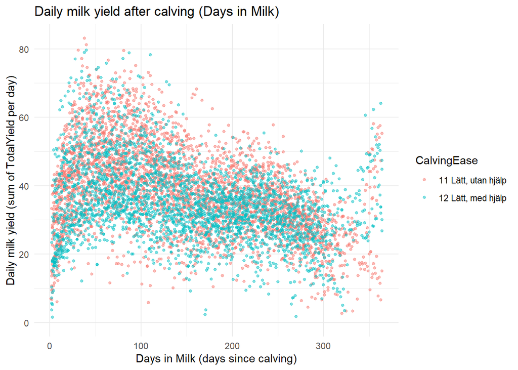

```r
# We plot milk yield by Days in Milk (DIM) instead of calendar date.
# ggplot2 is used for plotting
# Read more here: https://ggplot2.tidyverse.org/


# DIM = number of days since calving for each cow.
# This makes cows comparable even if they calved on different dates.

# IMPORTANT:
# DF.DailyMilkPerCow currently only contains StartDate (milking date), not CalvingDate.
# We therefore re-create a calving table server-side and join it to the daily milk table,
# then calculate DIM in R after collect().

# 1) Calving table (server-side, not collected)
DF.CalvingWithOffspring_db <- con %>%
  tbl(in_catalog("basregDWH", "apiSci", "factCattleReproductionView")) %>%
  filter(
    !is.na(Calving),
    StartDate >= as.Date("2021-01-01"),
    StartDate <= as.Date("2021-01-31")
  ) %>%
  transmute(
    Farm = Farm,
    SE_Number = SE_Number,
    CalvingDate = StartDate,
    CalvingEase = CalvingEase
  )

# 2) Daily milk per cow per date (R object from Step 10)
# Make sure StartDate is Date class
DF.DailyMilkPerCow <- DF.DailyMilkPerCow %>%
  mutate(StartDate = as.Date(StartDate))

# 3) Join daily milk to calving table and calculate Days in Milk (DIM)
DF.DailyMilkWithDIM <- DF.DailyMilkPerCow %>%
  inner_join(
    DF.CalvingWithOffspring_db %>% collect(),
    by = c("SE_Number", "CalvingEase")
  ) %>%
  mutate(
    CalvingDate = as.Date(CalvingDate),
    DIM = as.integer(StartDate - CalvingDate)  # days since calving
  ) %>%
  filter(DIM >= 0, DIM <= 365) # keep the first 365 days after calving

# 4) Plot dots (easier to interpret than lines when many cows overlap)
ggplot(
  DF.DailyMilkWithDIM,
  aes(x = DIM, y = DailyTotalYield, colour = CalvingEase)
) +
  geom_point(alpha = 0.5, size = 1) +
  scale_y_continuous(limits = c(0, NA)) + # Y axis starts at 0
  labs(
    title = "Daily milk yield after calving (Days in Milk)",
    x = "Days in Milk (days since calving)",
    y = "Daily milk yield (sum of TotalYield per day)",
    colour = "CalvingEase"
  ) +
  theme_minimal()
```

# Step 12: Save results and close the database connection

We will now save the milking dataset to your computer as a CSV file. You can imagine that we later will investigate the appropriate end of the lactation as we see sveral animals having started their next lactation in the plot.

After saving, we close the database connection. This is good practice and releases resources on both your computer and the Basreg server.

```r
# Save the milking data as a CSV file in your working directory
# The file will be saved in the folder returned by getwd()
# Read more here: https://www.rdocumentation.org/packages/utils/topics/write.csv
write.csv(DF.MilkingAfterCalving, "DF_MilkingAfterCalving.csv", row.names = FALSE)

# Close the database connection when you are done
# Using dbIsValid() avoids errors if the connection is already closed
# Read more here:
# - dbDisconnect(): https://dbi.r-dbi.org/reference/dbDisconnect.html
# - dbIsValid():    https://dbi.r-dbi.org/reference/dbIsValid.html
if (DBI::dbIsValid(con)) DBI::dbDisconnect(con)
```